# Risk Factor Analysis

## Outcome Variable

**Outcome Variable:** whz

## Predictor Variables

**Intervention Variable:** cleanck

**Adjustment Set:**

- arm
- sex
- W_mage
- meducyrs
- feducyrs
- hhwealth_quart
- W_nrooms
- W_nhh
- W_nchldlt5
- trth2o
- impfloor
- delta_meducyrs
- delta_feducyrs
- delta_hhwealth_quart
- delta_W_nrooms
- delta_W_nhh
- delta_W_nchldlt5
- delta_trth2o
- delta_impfloor

## Stratifying Variables

The analysis was stratified on these variable(s):

- agecat
- studyid
- country

## Data Summary

| agecat | studyid | country | cleanck | n_cell | n |
| --- | --- | --- | --- | --- | --- |
| Birth | ki0047075b-MAL-ED | PERU | 1 | 1 | 2 |
| Birth | ki0047075b-MAL-ED | PERU | 0 | 1 | 2 |
| Birth | ki0047075b-MAL-ED | SOUTH AFRICA | 1 | 1 | 2 |
| Birth | ki0047075b-MAL-ED | SOUTH AFRICA | 0 | 1 | 2 |
| Birth | ki1000108-CMC-V-BCS-2002 | INDIA | 1 | 37 | 88 |
| Birth | ki1000108-CMC-V-BCS-2002 | INDIA | 0 | 51 | 88 |
| Birth | ki1000108-IRC | INDIA | 1 | 198 | 337 |
| Birth | ki1000108-IRC | INDIA | 0 | 139 | 337 |
| Birth | ki1017093c-NIH-Crypto | BANGLADESH | 1 | 11 | 17 |
| Birth | ki1017093c-NIH-Crypto | BANGLADESH | 0 | 6 | 17 |
| 6 months | ki0047075b-MAL-ED | SOUTH AFRICA | 1 | 1 | 1 |
| 6 months | ki0047075b-MAL-ED | SOUTH AFRICA | 0 | 0 | 1 |
| 6 months | ki1000108-CMC-V-BCS-2002 | INDIA | 1 | 162 | 368 |
| 6 months | ki1000108-CMC-V-BCS-2002 | INDIA | 0 | 206 | 368 |
| 6 months | ki1000108-IRC | INDIA | 1 | 229 | 398 |
| 6 months | ki1000108-IRC | INDIA | 0 | 169 | 398 |
| 6 months | ki1017093b-PROVIDE | BANGLADESH | 1 | 481 | 582 |
| 6 months | ki1017093b-PROVIDE | BANGLADESH | 0 | 101 | 582 |
| 6 months | ki1017093c-NIH-Crypto | BANGLADESH | 1 | 329 | 545 |
| 6 months | ki1017093c-NIH-Crypto | BANGLADESH | 0 | 216 | 545 |
| 6 months | ki1113344-GMS-Nepal | NEPAL | 1 | 8 | 504 |
| 6 months | ki1113344-GMS-Nepal | NEPAL | 0 | 496 | 504 |
| 24 months | ki0047075b-MAL-ED | SOUTH AFRICA | 1 | 1 | 1 |
| 24 months | ki0047075b-MAL-ED | SOUTH AFRICA | 0 | 0 | 1 |
| 24 months | ki1000108-CMC-V-BCS-2002 | INDIA | 1 | 163 | 372 |
| 24 months | ki1000108-CMC-V-BCS-2002 | INDIA | 0 | 209 | 372 |
| 24 months | ki1000108-IRC | INDIA | 1 | 231 | 400 |
| 24 months | ki1000108-IRC | INDIA | 0 | 169 | 400 |
| 24 months | ki1017093b-PROVIDE | BANGLADESH | 1 | 480 | 578 |
| 24 months | ki1017093b-PROVIDE | BANGLADESH | 0 | 98 | 578 |
| 24 months | ki1017093c-NIH-Crypto | BANGLADESH | 1 | 199 | 410 |
| 24 months | ki1017093c-NIH-Crypto | BANGLADESH | 0 | 211 | 410 |
| 24 months | ki1113344-GMS-Nepal | NEPAL | 1 | 7 | 445 |
| 24 months | ki1113344-GMS-Nepal | NEPAL | 0 | 438 | 445 |

The following strata were considered:

- agecat: 24 months, studyid: ki0047075b-MAL-ED, country: SOUTH AFRICA
- agecat: 24 months, studyid: ki1000108-CMC-V-BCS-2002, country: INDIA
- agecat: 24 months, studyid: ki1000108-IRC, country: INDIA
- agecat: 24 months, studyid: ki1017093b-PROVIDE, country: BANGLADESH
- agecat: 24 months, studyid: ki1017093c-NIH-Crypto, country: BANGLADESH
- agecat: 24 months, studyid: ki1113344-GMS-Nepal, country: NEPAL
- agecat: 6 months, studyid: ki0047075b-MAL-ED, country: SOUTH AFRICA
- agecat: 6 months, studyid: ki1000108-CMC-V-BCS-2002, country: INDIA
- agecat: 6 months, studyid: ki1000108-IRC, country: INDIA
- agecat: 6 months, studyid: ki1017093b-PROVIDE, country: BANGLADESH
- agecat: 6 months, studyid: ki1017093c-NIH-Crypto, country: BANGLADESH
- agecat: 6 months, studyid: ki1113344-GMS-Nepal, country: NEPAL
- agecat: Birth, studyid: ki0047075b-MAL-ED, country: PERU
- agecat: Birth, studyid: ki0047075b-MAL-ED, country: SOUTH AFRICA
- agecat: Birth, studyid: ki1000108-CMC-V-BCS-2002, country: INDIA
- agecat: Birth, studyid: ki1000108-IRC, country: INDIA
- agecat: Birth, studyid: ki1017093c-NIH-Crypto, country: BANGLADESH

### Dropped Strata

Some strata were dropped due to rare outcomes:

- agecat: Birth, studyid: ki0047075b-MAL-ED, country: PERU
- agecat: Birth, studyid: ki0047075b-MAL-ED, country: SOUTH AFRICA
- agecat: 6 months, studyid: ki0047075b-MAL-ED, country: SOUTH AFRICA
- agecat: 24 months, studyid: ki0047075b-MAL-ED, country: SOUTH AFRICA

## Methods Detail

We’re interested in the causal parameters $E[Y_a]$ for all values of $a \in \mathcal{A}$. These parameters represent the mean outcome if, possibly contrary to fact, we intervened to set all units to have $A=a$. Under the randomization and positivity assumptions, these are identified by the statistical parameters $\psi_a=E_W[E_{Y|A,W}(Y|A=a,W)]$. In addition, we’re interested in the mean of $Y$, $E[Y]$ under no intervention (the observed mean). We will estimate these parameters by using SuperLearner to fit the relevant likelihood factors – $E_{Y|A,W}(Y|A=a,W)$ and $p(A=a|W)$, and then updating our likelihood fit using a joint TMLE.

For unadjusted analyses ($W=\{\}$), initial likelihoods were estimated using Lrnr_glm to estimate the simple $E(Y|A)$ and Lrnr_mean to estimate $p(A)$. For adjusted analyses, a small library containing Lrnr_glmnet, Lrnr_xgboost, and Lrnr_mean was used.

Having estimated these parameters, we will then use the delta method to estimate relative risks and attributable risks relative to a prespecified baseline level of $A$.

# Results Detail

## Results Plots

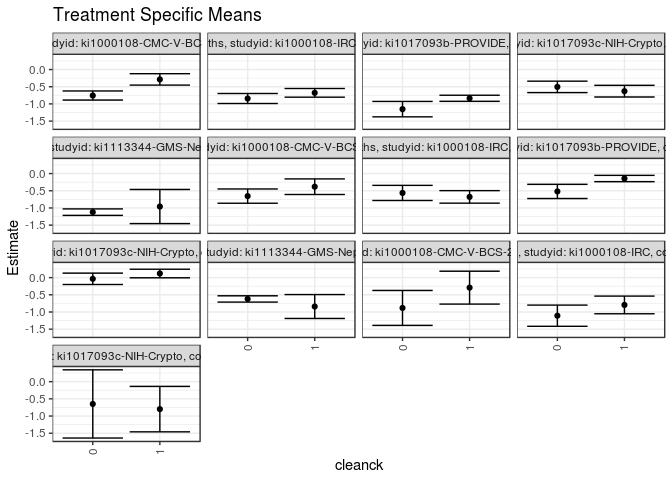

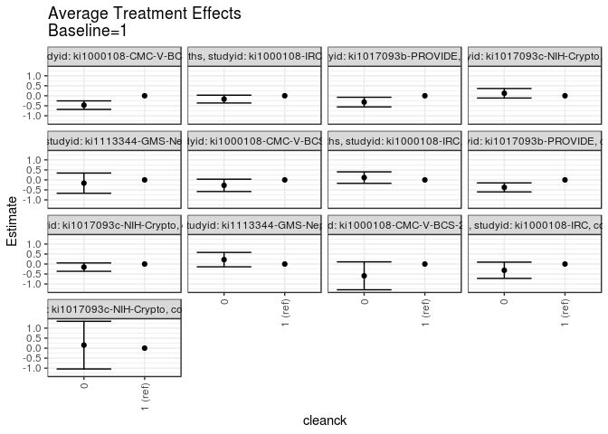

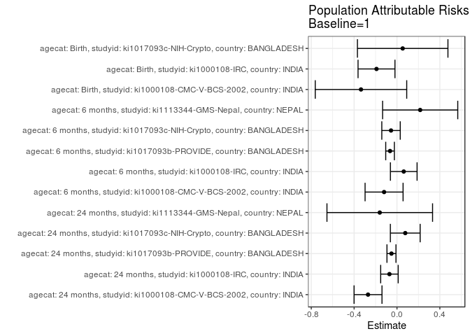

## Results Table

### Parameter: TSM

| agecat | studyid | country | intervention_level | baseline_level | estimate | ci_lower | ci_upper |
| --- | --- | --- | --- | --- | --- | --- | --- |
| Birth | ki1000108-CMC-V-BCS-2002 | INDIA | 1 | NA | -0.2914795 | -0.7697389 | 0.1867798 |
| Birth | ki1000108-CMC-V-BCS-2002 | INDIA | 0 | NA | -0.8819829 | -1.3898409 | -0.3741249 |
| Birth | ki1000108-IRC | INDIA | 1 | NA | -0.7949731 | -1.0517325 | -0.5382137 |
| Birth | ki1000108-IRC | INDIA | 0 | NA | -1.1081293 | -1.4167348 | -0.7995238 |
| Birth | ki1017093c-NIH-Crypto | BANGLADESH | 1 | NA | -0.7990909 | -1.4601804 | -0.1380015 |
| Birth | ki1017093c-NIH-Crypto | BANGLADESH | 0 | NA | -0.6483333 | -1.6406455 | 0.3439788 |
| 6 months | ki1000108-CMC-V-BCS-2002 | INDIA | 1 | NA | -0.3822337 | -0.6091658 | -0.1553016 |
| 6 months | ki1000108-CMC-V-BCS-2002 | INDIA | 0 | NA | -0.6555144 | -0.8628727 | -0.4481561 |
| 6 months | ki1000108-IRC | INDIA | 1 | NA | -0.6784626 | -0.8608250 | -0.4961002 |
| 6 months | ki1000108-IRC | INDIA | 0 | NA | -0.5630140 | -0.7832815 | -0.3427464 |
| 6 months | ki1017093b-PROVIDE | BANGLADESH | 1 | NA | -0.1436213 | -0.2349986 | -0.0522441 |
| 6 months | ki1017093b-PROVIDE | BANGLADESH | 0 | NA | -0.5193537 | -0.7257854 | -0.3129219 |
| 6 months | ki1017093c-NIH-Crypto | BANGLADESH | 1 | NA | 0.1197489 | -0.0050872 | 0.2445850 |
| 6 months | ki1017093c-NIH-Crypto | BANGLADESH | 0 | NA | -0.0352348 | -0.2007592 | 0.1302896 |
| 6 months | ki1113344-GMS-Nepal | NEPAL | 1 | NA | -0.8406250 | -1.1883379 | -0.4929121 |
| 6 months | ki1113344-GMS-Nepal | NEPAL | 0 | NA | -0.6206788 | -0.7126572 | -0.5287003 |
| 24 months | ki1000108-CMC-V-BCS-2002 | INDIA | 1 | NA | -0.2869522 | -0.4531290 | -0.1207754 |
| 24 months | ki1000108-CMC-V-BCS-2002 | INDIA | 0 | NA | -0.7556994 | -0.8879904 | -0.6234084 |
| 24 months | ki1000108-IRC | INDIA | 1 | NA | -0.6774796 | -0.8034661 | -0.5514931 |
| 24 months | ki1000108-IRC | INDIA | 0 | NA | -0.8431393 | -0.9885896 | -0.6976890 |
| 24 months | ki1017093b-PROVIDE | BANGLADESH | 1 | NA | -0.8363598 | -0.9246886 | -0.7480309 |
| 24 months | ki1017093b-PROVIDE | BANGLADESH | 0 | NA | -1.1521573 | -1.3765320 | -0.9277826 |
| 24 months | ki1017093c-NIH-Crypto | BANGLADESH | 1 | NA | -0.6290035 | -0.7986535 | -0.4593535 |
| 24 months | ki1017093c-NIH-Crypto | BANGLADESH | 0 | NA | -0.5046614 | -0.6710066 | -0.3383162 |
| 24 months | ki1113344-GMS-Nepal | NEPAL | 1 | NA | -0.9585714 | -1.4549933 | -0.4621496 |
| 24 months | ki1113344-GMS-Nepal | NEPAL | 0 | NA | -1.1218379 | -1.2165987 | -1.0270771 |

### Parameter: E(Y)

| agecat | studyid | country | intervention_level | baseline_level | estimate | ci_lower | ci_upper |
| --- | --- | --- | --- | --- | --- | --- | --- |
| Birth | ki1000108-CMC-V-BCS-2002 | INDIA | NA | NA | -0.6275000 | -0.9746292 | -0.2803708 |
| Birth | ki1000108-IRC | INDIA | NA | NA | -0.9860831 | -1.1746070 | -0.7975591 |
| Birth | ki1017093c-NIH-Crypto | BANGLADESH | NA | NA | -0.7458824 | -1.2998567 | -0.1919080 |
| 6 months | ki1000108-CMC-V-BCS-2002 | INDIA | NA | NA | -0.5026766 | -0.6536848 | -0.3516685 |
| 6 months | ki1000108-IRC | INDIA | NA | NA | -0.6153685 | -0.7522411 | -0.4784959 |
| 6 months | ki1017093b-PROVIDE | BANGLADESH | NA | NA | -0.2083706 | -0.2927992 | -0.1239419 |
| 6 months | ki1017093c-NIH-Crypto | BANGLADESH | NA | NA | 0.0640826 | -0.0252594 | 0.1534245 |
| 6 months | ki1113344-GMS-Nepal | NEPAL | NA | NA | -0.6241700 | -0.7143013 | -0.5340386 |
| 24 months | ki1000108-CMC-V-BCS-2002 | INDIA | NA | NA | -0.5571505 | -0.6585247 | -0.4557763 |
| 24 months | ki1000108-IRC | INDIA | NA | NA | -0.7479083 | -0.8403586 | -0.6554581 |
| 24 months | ki1017093b-PROVIDE | BANGLADESH | NA | NA | -0.8879412 | -0.9708680 | -0.8050144 |
| 24 months | ki1017093c-NIH-Crypto | BANGLADESH | NA | NA | -0.5518293 | -0.6602513 | -0.4434072 |
| 24 months | ki1113344-GMS-Nepal | NEPAL | NA | NA | -1.1192697 | -1.2125104 | -1.0260289 |

### Parameter: ATE

| agecat | studyid | country | intervention_level | baseline_level | estimate | ci_lower | ci_upper |
| --- | --- | --- | --- | --- | --- | --- | --- |
| Birth | ki1000108-CMC-V-BCS-2002 | INDIA | 1 | 1 | 0.0000000 | 0.0000000 | 0.0000000 |
| Birth | ki1000108-CMC-V-BCS-2002 | INDIA | 0 | 1 | -0.5905033 | -1.2896771 | 0.1086704 |
| Birth | ki1000108-IRC | INDIA | 1 | 1 | 0.0000000 | 0.0000000 | 0.0000000 |
| Birth | ki1000108-IRC | INDIA | 0 | 1 | -0.3131562 | -0.7196868 | 0.0933744 |
| Birth | ki1017093c-NIH-Crypto | BANGLADESH | 1 | 1 | 0.0000000 | 0.0000000 | 0.0000000 |
| Birth | ki1017093c-NIH-Crypto | BANGLADESH | 0 | 1 | 0.1507576 | -1.0416025 | 1.3431177 |
| 6 months | ki1000108-CMC-V-BCS-2002 | INDIA | 1 | 1 | 0.0000000 | 0.0000000 | 0.0000000 |
| 6 months | ki1000108-CMC-V-BCS-2002 | INDIA | 0 | 1 | -0.2732807 | -0.5811840 | 0.0346225 |
| 6 months | ki1000108-IRC | INDIA | 1 | 1 | 0.0000000 | 0.0000000 | 0.0000000 |
| 6 months | ki1000108-IRC | INDIA | 0 | 1 | 0.1154486 | -0.1713246 | 0.4022218 |
| 6 months | ki1017093b-PROVIDE | BANGLADESH | 1 | 1 | 0.0000000 | 0.0000000 | 0.0000000 |
| 6 months | ki1017093b-PROVIDE | BANGLADESH | 0 | 1 | -0.3757323 | -0.6011111 | -0.1503536 |
| 6 months | ki1017093c-NIH-Crypto | BANGLADESH | 1 | 1 | 0.0000000 | 0.0000000 | 0.0000000 |
| 6 months | ki1017093c-NIH-Crypto | BANGLADESH | 0 | 1 | -0.1549837 | -0.3626536 | 0.0526861 |
| 6 months | ki1113344-GMS-Nepal | NEPAL | 1 | 1 | 0.0000000 | 0.0000000 | 0.0000000 |
| 6 months | ki1113344-GMS-Nepal | NEPAL | 0 | 1 | 0.2199462 | -0.1397262 | 0.5796187 |
| 24 months | ki1000108-CMC-V-BCS-2002 | INDIA | 1 | 1 | 0.0000000 | 0.0000000 | 0.0000000 |
| 24 months | ki1000108-CMC-V-BCS-2002 | INDIA | 0 | 1 | -0.4687472 | -0.6819574 | -0.2555370 |
| 24 months | ki1000108-IRC | INDIA | 1 | 1 | 0.0000000 | 0.0000000 | 0.0000000 |
| 24 months | ki1000108-IRC | INDIA | 0 | 1 | -0.1656597 | -0.3609915 | 0.0296721 |
| 24 months | ki1017093b-PROVIDE | BANGLADESH | 1 | 1 | 0.0000000 | 0.0000000 | 0.0000000 |
| 24 months | ki1017093b-PROVIDE | BANGLADESH | 0 | 1 | -0.3157976 | -0.5572247 | -0.0743705 |
| 24 months | ki1017093c-NIH-Crypto | BANGLADESH | 1 | 1 | 0.0000000 | 0.0000000 | 0.0000000 |
| 24 months | ki1017093c-NIH-Crypto | BANGLADESH | 0 | 1 | 0.1243421 | -0.1133284 | 0.3620127 |
| 24 months | ki1113344-GMS-Nepal | NEPAL | 1 | 1 | 0.0000000 | 0.0000000 | 0.0000000 |
| 24 months | ki1113344-GMS-Nepal | NEPAL | 0 | 1 | -0.1632665 | -0.6686517 | 0.3421188 |

### Parameter: PAR

| agecat | studyid | country | intervention_level | baseline_level | estimate | ci_lower | ci_upper |
| --- | --- | --- | --- | --- | --- | --- | --- |
| Birth | ki1000108-CMC-V-BCS-2002 | INDIA | 1 | NA | -0.3360205 | -0.7628514 | 0.0908105 |
| Birth | ki1000108-IRC | INDIA | 1 | NA | -0.1911100 | -0.3633246 | -0.0188954 |
| Birth | ki1017093c-NIH-Crypto | BANGLADESH | 1 | NA | 0.0532086 | -0.3691024 | 0.4755196 |
| 6 months | ki1000108-CMC-V-BCS-2002 | INDIA | 1 | NA | -0.1204429 | -0.2977125 | 0.0568266 |
| 6 months | ki1000108-IRC | INDIA | 1 | NA | 0.0630941 | -0.0613071 | 0.1874953 |
| 6 months | ki1017093b-PROVIDE | BANGLADESH | 1 | NA | -0.0647492 | -0.1050371 | -0.0244613 |
| 6 months | ki1017093c-NIH-Crypto | BANGLADESH | 1 | NA | -0.0556663 | -0.1416824 | 0.0303497 |
| 6 months | ki1113344-GMS-Nepal | NEPAL | 1 | NA | 0.2164550 | -0.1342338 | 0.5671439 |
| 24 months | ki1000108-CMC-V-BCS-2002 | INDIA | 1 | NA | -0.2701984 | -0.4004571 | -0.1399396 |
| 24 months | ki1000108-IRC | INDIA | 1 | NA | -0.0704288 | -0.1520483 | 0.0111908 |
| 24 months | ki1017093b-PROVIDE | BANGLADESH | 1 | NA | -0.0515814 | -0.0935254 | -0.0096374 |
| 24 months | ki1017093c-NIH-Crypto | BANGLADESH | 1 | NA | 0.0771743 | -0.0617494 | 0.2160979 |
| 24 months | ki1113344-GMS-Nepal | NEPAL | 1 | NA | -0.1606982 | -0.6534525 | 0.3320560 |